# Project 3

Jianqiao Wang

#### Backgroud and Introduction

[Urban Ministries of Durham (UMD)](http://www.umdurham.org/) is a program that helps homeless people by providing neighbors with emergency shelter and case management to help them overcome barriers such as unemployment, medical and mental health problems, past criminal convictions and addiction. This dataset is from the shelter side of UMD. It includes a lot of data about clients upon entry to and exit from the shelter, including age, gender, race, mental health, income, insurance, and many other variables spread across many tables.

The main purpose of this project is to test whether client demographics have an effect on their length of stay in UMD. Specifically, we are interested in the effects of age, gender, race, ethnicity and veteran status. The following table presents ranges for these covariates:

| Covariate | Value |
| --- | --- |
| Race | American Indian or Alaska Native, White, Asian, Native Hawaiian or Other Pacific Islander, Black or African American |
| Ethnicity | Non-Hispanic/Non-Latino, Hispanic/Latino |
| VeteranStatus | No, Yes |
| Gender | Female, Male, Trans Female (MTF or Male to Female) |
| Age | [18 ,81] |

We will first plot the correlation between duration in UMD and different covariates. Then, we will use hypothesis tests to test each covariate’s effect.

#### Density Plot and Histograms

First of all, we give the estimated density plot of duration

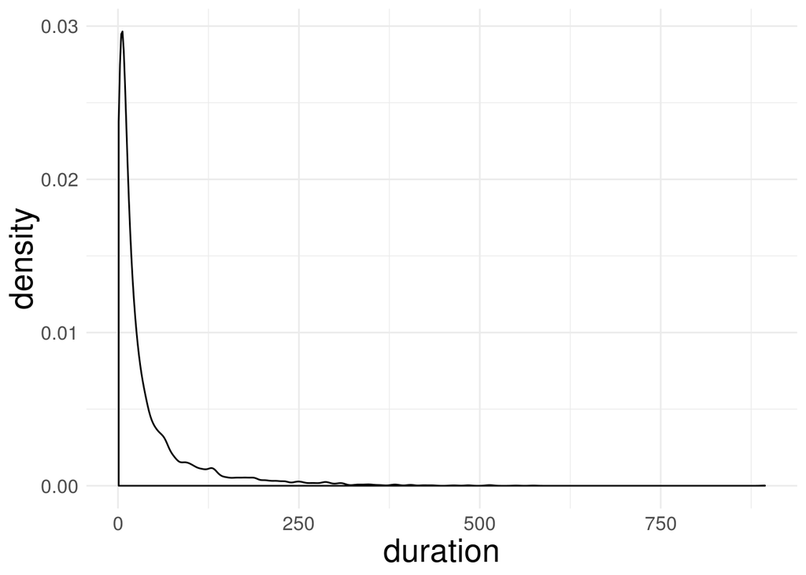

As we can see, the density of duration is a decreasing function, which is similar to exponential distribution or gamma distribution. Moreover, the histograms of duration grouped by different covariates are as follow:

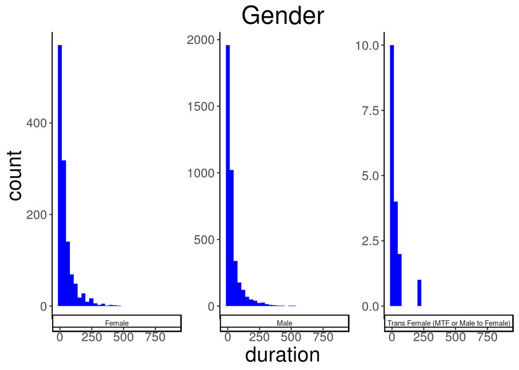

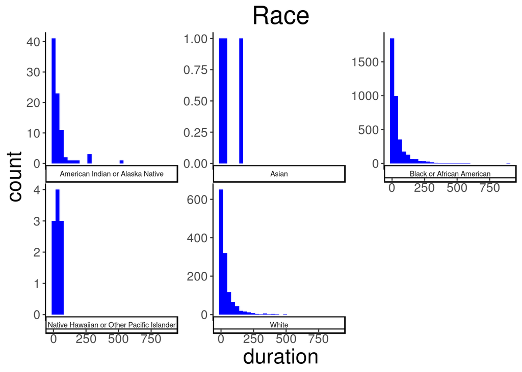

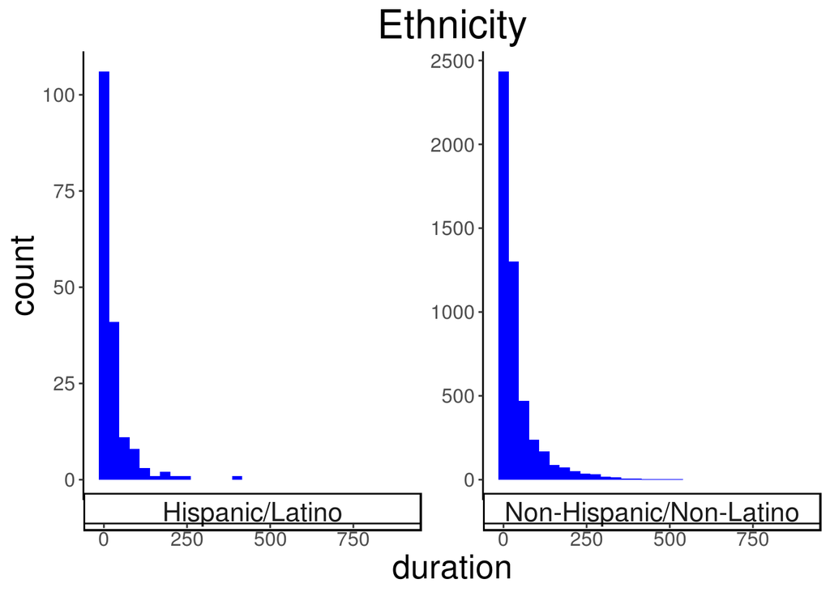

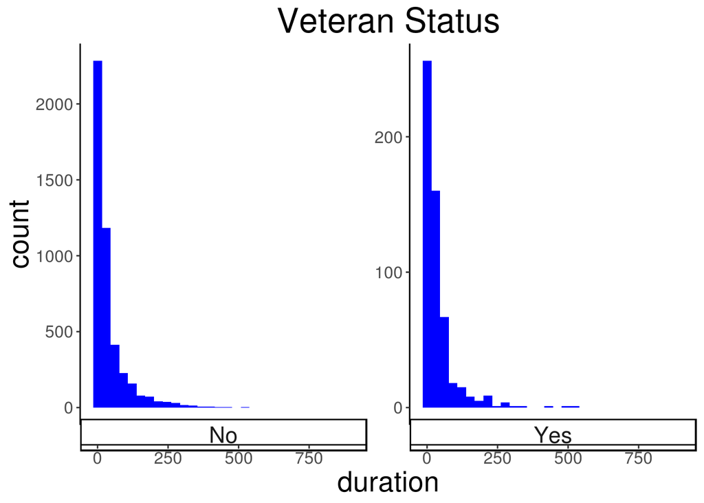

Similarly with the density plot of duration without considering any covariates, the density plots of duration grouped by different covariates are decreasing, with higher density near zero. Therefore, it is reasonalbe to use gamma regression to test effects of these covariates.

#### Gamma Regression

Gamma regression is a specific method in generalized linear models. There are two basic assumptions for gamma regression:

- Distribution assumption: $y_i\sim G(\mu_i, \nu)$ for $i=1,\cdots,n$, where $G(\mu, \nu)$ denotes the gamma distribution with mean $\mu$ and shape parameter $\nu>0$.
- Structural assumption: $\mu_i$ is related to $x_i$ by
  $$g(\mu_i)=x_i^{T}\beta$$
  for $i=1,\cdots,n$, where $g(\cdot)$ is a given monotone link function and $\beta$ is defined in a $\mathcal{R}^{p}$.

#### Hypothesis Test

For our model, let ‘Female’, ‘Hispanic/Latino’, ‘American Indian or Alaska Native’, ‘No’ be reference groups for gender, ethnicity, race and veteran status respectively. The summary of Gamma regression is as follows:

```
<class 'statsmodels.iolib.summary.Summary'>
"""
                 Generalized Linear Model Regression Results
==============================================================================
Dep. Variable:               duration   No. Observations:                 5125
Model:                            GLM   Df Residuals:                     5115
Model Family:                   Gamma   Df Model:                            9
Link Function:               identity   Scale:                   2.40997858525
Method:                          IRLS   Log-Likelihood:                -23863.
Date:                Thu, 28 Nov 2019   Deviance:                       9582.6
Time:                        11:07:03   Pearson chi2:                 1.23e+04
No. Iterations:                     9
=====================================================================================================================
                                                        coef    std err          z      P>|z|      [0.025      0.975]
---------------------------------------------------------------------------------------------------------------------
Intercept                                             9.3277      7.305      1.277      0.202      -4.989      23.644
Gender[T.Male]                                       -5.9836      2.084     -2.871      0.004     -10.068      -1.899
Gender[T.Trans Female (MTF or Male to Female)]       -7.2215     12.036     -0.600      0.548     -30.811      16.368
Ethnicity[T.Non-Hispanic/Non-Latino]                 12.0658      3.050      3.956      0.000       6.088      18.044
Race[T.Asian]                                        33.0371     56.981      0.580      0.562     -78.643     144.717
Race[T.Black or African American]                     2.2976      6.093      0.377      0.706      -9.644      14.239
Race[T.Native Hawaiian or Other Pacific Islander]    -4.4698     13.911     -0.321      0.748     -31.735      22.795
Race[T.White]                                        -1.6757      6.210     -0.270      0.787     -13.847      10.496
VeteranStatus[T.Yes]                                 -7.1503      2.638     -2.711      0.007     -12.320      -1.980
Age                                                   0.5167      0.064      8.087      0.000       0.391       0.642
=====================================================================================================================
"""
```

As we can see, under 0.05 significance level, race doesn’t have effects on duration. Moreover, gender, ethnicity and veteran status have effect on duration. Since our link function is an increasing function, specifically,

- Male has negative effect on duration comparing to female.
- Non-Hispanic/Non-Latino have positive effect on duration comparing to Hispanic/Latino.
- Veterans has negative effect on duration comparing to those who are not veterans.
- Age has positive effect on duration. In other words, older clients will stay longer.